# Week 6

Cindy Hayward

2017-04-25

## Case Study: Hometown Bank

Hometown Bank would like to understand and improve its status in the term deposit market. The bank has provided two different versions of a data set: a large version with 45,211 rows (bank-full.csv) and a sampled, smaller version with 4,000 rows (bank.csv). The dataset contains 17 variables. The bank would prefer we use the full data set in the analysis. The variable the bank is most interested in understanding is “y::category”, which refers to whether the client has subscribed a term deposit. It is a factor with two levels: “yes” or “no.”

The bank would like to understand what factors contribute to the customer opting for a term deposit, if there are any similar qualities that would indicate that the customer would opt in, and/or if we can identify the profile of the customer likely to purchase a term deposit.

Using the large dataset provided, we will utilize three different models:  
Logistic Regression  
Decision Tree Algorithm Bagging Random Forest

```
## [1] "C:/Users/cindyHayward/Desktop/ADM/Week_Six/Week_Six_Class"
```

```
##   age..number job..category marital..category education..category
## 1          58    management           married            tertiary
## 2          44    technician            single           secondary
## 3          33  entrepreneur           married           secondary
## 4          47   blue-collar           married             unknown
## 5          33       unknown            single             unknown
## 6          35    management           married            tertiary
##   default..category balance..number housing..category loan..category
## 1                no            2143               yes             no
## 2                no              29               yes             no
## 3                no               2               yes            yes
## 4                no            1506               yes             no
## 5                no               1                no             no
## 6                no             231               yes             no
##   contact..category day..number month..category duration..number
```

[output cut: 20 more lines]

```
## [1] 45211    13
```

```
##
##    no   yes
## 39922  5289
```

**Exploring the Data**

The original data set is made up of 45,211 records, containing 17 variables. All variables which will not help us answer the question of “Who will buy a term deposit?” have been eliminated for the purpose of our analysis.

The data related to the marketing campaign could be helpful in future projects to analyze what is effective relative to marketing campaigns. The initial look at the dataset in its entirety, showed that duration, and some date information was significant. These variables can be useful for the development of the next campaign, once we have determined whom the bank should target to market term deposits to. A description of the variable follows:

y..category– indicates whether the customer subscribed to the term deposit  
default..category– Has credit with the bank in default  
housing..category– Does the customer have a mortgage account  
loan..category– Has a personal loan  
job..category– possible values: bluecollar, entrepreneur, housemaid, management, retired, selfemployed, services, student, technician, unemployed, unknown  
marital..category– with the possible values, Married, Single, Divorced  
education..category– with the possible values: Tertiary, Secondary,Primary  
balance..number– average account balance  
GenZ– account holders aged less than 22  
Millenial– account holders ages 22-37  
GenY– account holders ages 38-52  
Boomer– account holders ages 63-71  
SilentGen– account holders over 72

**Dividing the Data Set**

```
##
##        no       yes
## 0.8840191 0.1159809
```

```
##
##        no       yes
## 0.8789894 0.1210106
```

**Logistic Regression Analysis** A traditional method of classification is logistic regression, or odds ratios. In other words, given a certain characteristic, what are the odds that an outcome will take place. The initial model looked at all data points for each individual record. All attributes except job..unemployed and SilentGen were statistically significant. The term statistically significant means that there is almost zero chance that the result is a matter of chance.

**Key Takeaways:**

```
##
## Call:
## glm(formula = y..category ~ ., family = binomial(), data = bank_Train)
##
## Deviance Residuals:
##     Min       1Q   Median       3Q      Max
## -1.5843  -0.5318  -0.4294  -0.3408   2.8644
##
## Coefficients: (1 not defined because of singularities)
##                                  Estimate   Std. Error z value
## (Intercept)                  -0.622034065  0.152641780  -4.075
## job..categoryblue-collar     -0.363710045  0.067212621  -5.411
## job..categoryentrepreneur    -0.552679889  0.121595510  -4.545
## job..categoryhousemaid       -0.460878460  0.125818421  -3.663
## job..categorymanagement      -0.216286809  0.067756632  -3.192
## job..categoryretired          0.245293788  0.091776761   2.673
## job..categoryself-employed   -0.327279025  0.104149758  -3.142
## job..categoryservices        -0.336300832  0.078144888  -4.304
## job..categorystudent          0.399016839  0.104047894   3.835
## job..categorytechnician      -0.285512549  0.063511237  -4.495
## job..categoryunemployed       0.025534482  0.099969775   0.255
## job..categoryunknown         -0.564901713  0.222428188  -2.540
## marital..categorymarried     -0.179947903  0.054314739  -3.313
## marital..categorysingle       0.124308673  0.061305884   2.028
## education..categorysecondary  0.279480737  0.060675881   4.606
## education..categorytertiary   0.500053133  0.070393535   7.104
## education..categoryunknown    0.281721986  0.096554873   2.918
## default..categoryyes         -0.436275037  0.162350916  -2.687
## balance..number               0.000023154  0.000004418   5.241
## housing..categoryyes         -0.707165264  0.036113473 -19.582
## loan..categoryyes            -0.534993208  0.056512612  -9.467
## GenZ                         -0.669890502  0.240649115  -2.784
## Millenial                    -1.048226468  0.139147944  -7.533
## GenY                         -1.231340726  0.137086010  -8.982
## Boomer                       -1.006507397  0.128269693  -7.847
## SilentGen                              NA           NA      NA
##                                          Pr(>|z|)
## (Intercept)                   0.00004598998503705 ***
## job..categoryblue-collar      0.00000006255643364 ***
## job..categoryentrepreneur     0.00000548745894429 ***
```

[output cut: 18 more lines]

```
## GenZ                                     0.005375 **
## Millenial                     0.00000000000004952 ***
## GenY                         < 0.0000000000000002 ***
## Boomer                        0.00000000000000427 ***
## SilentGen                                      NA
## ---
## Signif. codes:  0 '***' 0.001 '**' 0.01 '*' 0.05 '.' 0.1 ' ' 1
##
## (Dispersion parameter for binomial family taken to be 1)
##
##     Null deviance: 25971  on 36186  degrees of freedom
## Residual deviance: 24530  on 36162  degrees of freedom
## AIC: 24580
##
## Number of Fisher Scoring iterations: 5
```

```
##                              Odds_Ratio
## (Intercept)                   0.5368513
## job..categoryblue-collar      0.6950927
## job..categoryentrepreneur     0.5754057
## job..categoryhousemaid        0.6307293
## job..categorymanagement       0.8055042
## job..categoryretired          1.2779967
## job..categoryself-employed    0.7208826
## job..categoryservices         0.7144082
## job..categorystudent          1.4903587
## job..categorytechnician       0.7516289
## job..categoryunemployed       1.0258633
## job..categoryunknown          0.5684160
## marital..categorymarried      0.8353137
## marital..categorysingle       1.1323653
## education..categorysecondary  1.3224429
## education..categorytertiary   1.6488089
## education..categoryunknown    1.3254102
## default..categoryyes          0.6464399
## balance..number               1.0000232
## housing..categoryyes          0.4930399
## loan..categoryyes             0.5856733
## GenZ                          0.5117646
## Millenial                     0.3505589
## GenY                          0.2919010
## Boomer                        0.3654933
## SilentGen                            NA
```

#### Checking to determine if the model is statistically significant.

```
## Analysis of Deviance Table
##
## Model: binomial, link: logit
##
## Response: y..category
##
## Terms added sequentially (first to last)
##
##
##                     Df Deviance Resid. Df Resid. Dev              Pr(>Chi)
## NULL                                36186      25971
## job..category       11   588.07     36175      25383 < 0.00000000000000022
## marital..category    2    97.85     36173      25285 < 0.00000000000000022
## education..category  3    62.58     36170      25222    0.0000000000001652
## default..category    1    14.59     36169      25208             0.0001339
## balance..number      1    47.75     36168      25160    0.0000000000048316
## housing..category    1   428.61     36167      24731 < 0.00000000000000022
## loan..category       1   107.27     36166      24624 < 0.00000000000000022
## GenZ                 1     3.65     36165      24620             0.0559450
## Millenial            1    11.64     36164      24609             0.0006459
## GenY                 1    19.25     36163      24589    0.0000114446980935
## Boomer               1    59.12     36162      24530    0.0000000000000148
## SilentGen            0     0.00     36162      24530
##
## NULL
## job..category       ***
## marital..category   ***
## education..category ***
## default..category   ***
## balance..number     ***
## housing..category   ***
## loan..category      ***
## GenZ                .
## Millenial           ***
## GenY                ***
## Boomer              ***
## SilentGen
## ---
## Signif. codes:  0 '***' 0.001 '**' 0.01 '*' 0.05 '.' 0.1 ' ' 1
```

### Decision Tree Algorithms

Classification trees, often called decision trees, are one method utilized to predict behavior. The benefit of using decision trees is the ease with which they can be interpreted or read. The decision tree incorporates much smaller splits and many more “leaves” at the bottom of the model.

```r
library(caret)
```

[figure not shown]

```r
library(rpart)
library(rpart.plot)
library(partykit)
set.seed(123)

bank_rpart<-rpart(y..category~.,data = bank_Train, control = rpart.control(minsplit = 80, cp=.0003))

plot(bank_rpart, uniform=TRUE, main="Classification Tree for Term Deposit")
text(bank_rpart, use.n=TRUE, all=TRUE, cex=0.8)
```

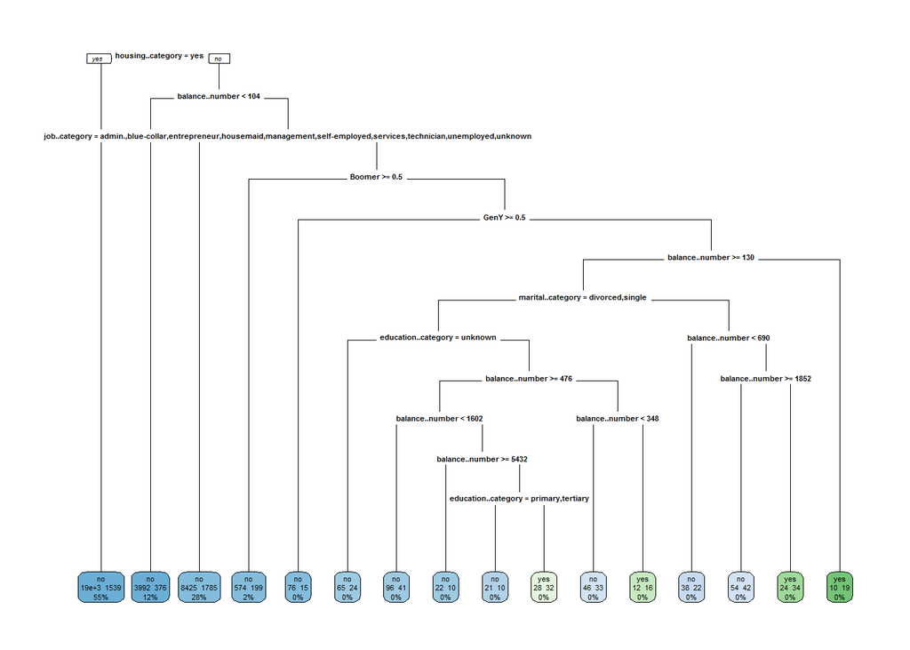

```r
rpart.plot(bank_rpart, type=0, extra=101)
```

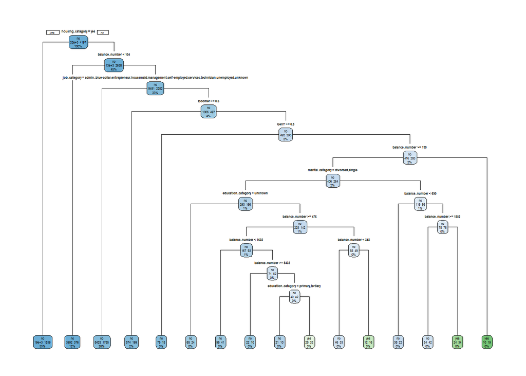

```r
rpart.plot(bank_rpart, type=1, extra=101)
```

```r
actual <- bank_Train$y..category
predicted <- predict(bank_rpart, bank_Test)

library(caret)
library(partykit)
```

## Bagging

Bagging averages many trees so it reduces the variance of the instability of generating just one tree. Bagging leads to improved prediction. The tradeoff is you lose interpretability and the ability to see simple structure in a tree.

```
##
## Call:
##  randomForest(formula = y..category ~ ., data = bank_Test, mtry = 8,      importance = TRUE, na.action = na.omit)
##                Type of random forest: classification
##                      Number of trees: 500
## No. of variables tried at each split: 8
##
##         OOB estimate of  error rate: 13.3%
## Confusion matrix:
##       no yes class.error
## no  7673 259  0.03265255
## yes  941 151  0.86172161
```

** Most Important Predictors Using Bagging **

Look at the mean decrease in node impurity resulting from splits over that variable.

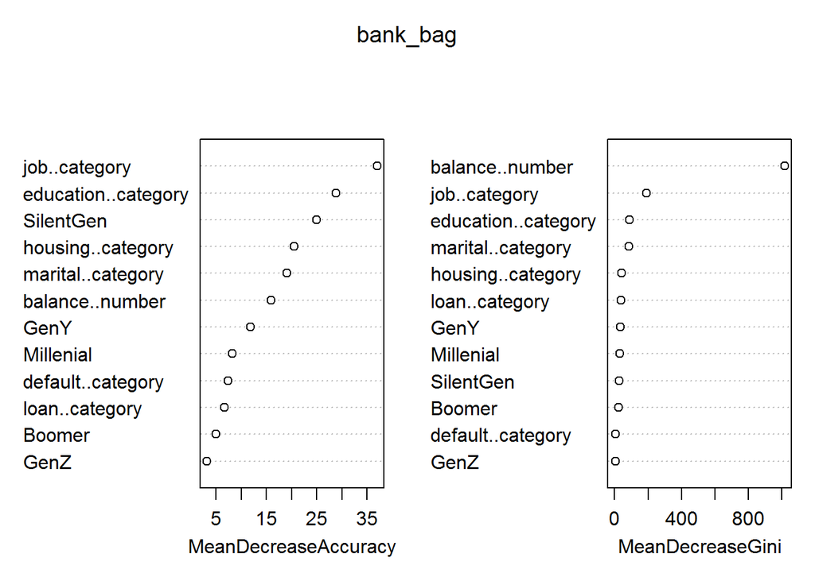

```
## Confusion Matrix and Statistics
##
##           Reference
## Prediction   no  yes
##        no  7922  274
##        yes   10  818
##
##                Accuracy : 0.9685
##                  95% CI : (0.9647, 0.972)
##     No Information Rate : 0.879
##     P-Value [Acc > NIR] : < 0.00000000000000022
##
##                   Kappa : 0.8348
##  Mcnemar's Test P-Value : < 0.00000000000000022
##
##             Sensitivity : 0.74908
##             Specificity : 0.99874
##          Pos Pred Value : 0.98792
##          Neg Pred Value : 0.96657
##              Prevalence : 0.12101
##          Detection Rate : 0.09065
##    Detection Prevalence : 0.09176
##       Balanced Accuracy : 0.87391
##
##        'Positive' Class : yes
##
```

## Random Forest

```
##
## Call:
##  randomForest(formula = y..category ~ ., data = bank_Train, mtry = 12,      ntree = 500, importance = TRUE, na.action = na.omit)
##                Type of random forest: classification
##                      Number of trees: 500
## No. of variables tried at each split: 12
##
##         OOB estimate of  error rate: 12.51%
## Confusion matrix:
##        no  yes class.error
## no  30478 1512  0.04726477
## yes  3016 1181  0.71860853
```

```
## Confusion Matrix and Statistics
##
##           Reference
## Prediction   no  yes
##        no  7553  787
##        yes  379  305
##
##                Accuracy : 0.8708
##                  95% CI : (0.8637, 0.8776)
##     No Information Rate : 0.879
##     P-Value [Acc > NIR] : 0.9915
##
##                   Kappa : 0.276
##  Mcnemar's Test P-Value : <0.0000000000000002
##
##             Sensitivity : 0.2793
##             Specificity : 0.9522
##          Pos Pred Value : 0.4459
##          Neg Pred Value : 0.9056
##              Prevalence : 0.1210
##          Detection Rate : 0.0338
##    Detection Prevalence : 0.0758
##       Balanced Accuracy : 0.6158
##
##        'Positive' Class : yes
##
```

**Evaluating the Performance**

The accuracy rate of 87%, which represents the overall accuracy of how often a prediction is correct. Other measures commonly used are specificity, which measures the percentage of how often predicted purchase actually occurs, in this case 95%. Precision, the percentage of predicted false that is truly false, is high, at 90%. Sensitivity measurement, the percentage of the model that is correct, is 28%. Overall, a lessor performance against Bagging.

**Visualizing the True Positive vs. False Positive**

Called the ROC curve, this displays the true positive rate (sensitivity) against the false positive rate (specificity). Ideally, the curve will follow the left hand borders. Ours is…okay.

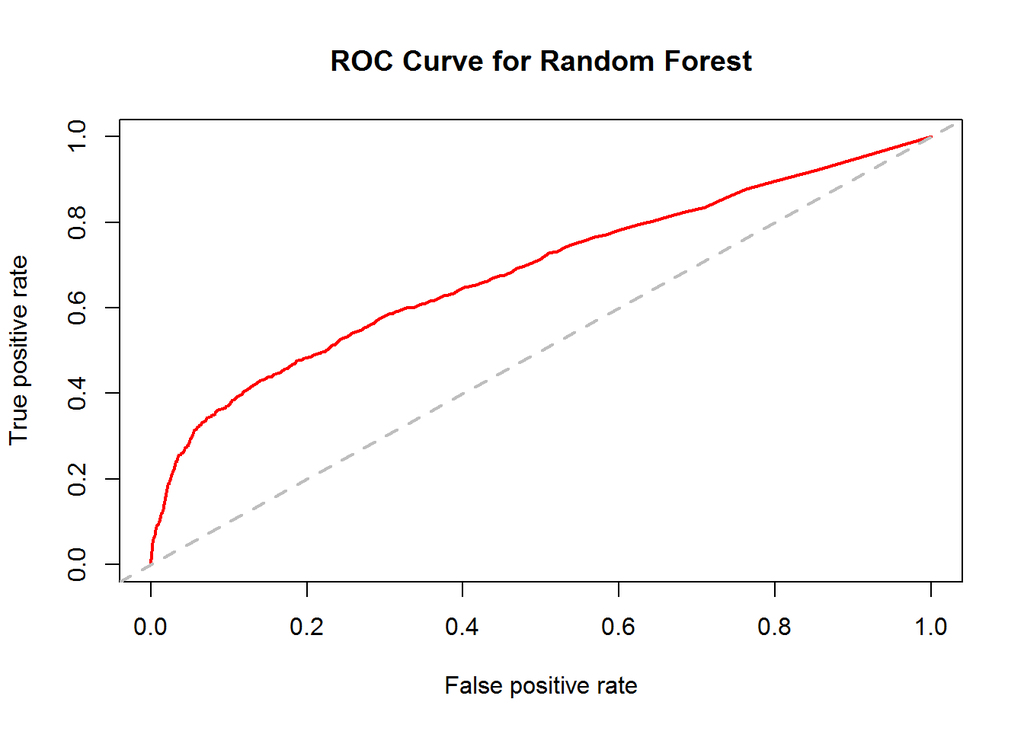